# Forecasting Section 5.8

Seema Rani Kanuri

April 17, 2017

# Question 1:

The data below (data set fancy) concern the monthly sales figures of a shop which opened in January 1987 and sells gifts, souvenirs, and novelties. The shop is situated on the wharf at a beach resort town in Queensland, Australia. The sales volume varies with the seasonal population of tourists. There is a large influx of visitors to the town at Christmas and for the local surfing festival, held every March since 1988. Over time, the shop has expanded its premises, range of products, and staff.

## a. Produce a time plot of the data and describe the patterns in the graph. Identify any unusual or unexpected fluctuations in the time series.

```r
#Including the required library

library(fma)
library(fpp)
```

```r
# Given data below (data set fancy) concern the monthly sales figures of a shop
fancy
```

```
##            Jan       Feb       Mar       Apr       May       Jun       Jul
## 1987   1664.81   2397.53   2840.71   3547.29   3752.96   3714.74   4349.61
## 1988   2499.81   5198.24   7225.14   4806.03   5900.88   4951.34   6179.12
## 1989   4717.02   5702.63   9957.58   5304.78   6492.43   6630.80   7349.62
## 1990   5921.10   5814.58  12421.25   6369.77   7609.12   7224.75   8121.22
## 1991   4826.64   6470.23   9638.77   8821.17   8722.37  10209.48  11276.55
## 1992   7615.03   9849.69  14558.40  11587.33   9332.56  13082.09  16732.78
## 1993  10243.24  11266.88  21826.84  17357.33  15997.79  18601.53  26155.15
##            Aug       Sep       Oct       Nov       Dec
## 1987   3566.34   5021.82   6423.48   7600.60  19756.21
## 1988   4752.15   5496.43   5835.10  12600.08  28541.72
## 1989   8176.62   8573.17   9690.50  15151.84  34061.01
## 1990   7979.25   8093.06   8476.70  17914.66  30114.41
## 1991  12552.22  11637.39  13606.89  21822.11  45060.69
## 1992  19888.61  23933.38  25391.35  36024.80  80721.71
## 1993  28586.52  30505.41  30821.33  46634.38 104660.67
```

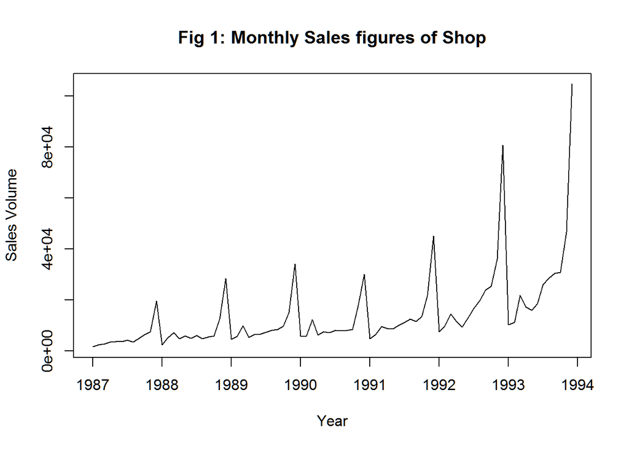

```r
#time plot of the data
plot(fancy,ylab="Sales Volume", xlab="Year", main="Fig 1: Monthly Sales figures of Shop")
```

## b. Explain why it is necessary to take logarithms of these data before fitting a model.

It appears that an additive model is not appropriate for describing this time series, since the size of the seasonal fluctuations and random fluctuations seem to increase with the level of the time series. Thus, we may need to transform the time series in order to get a transformed time series that can be described using an additive model. For example, we can transform the time series by calculating the natural log of the original data.

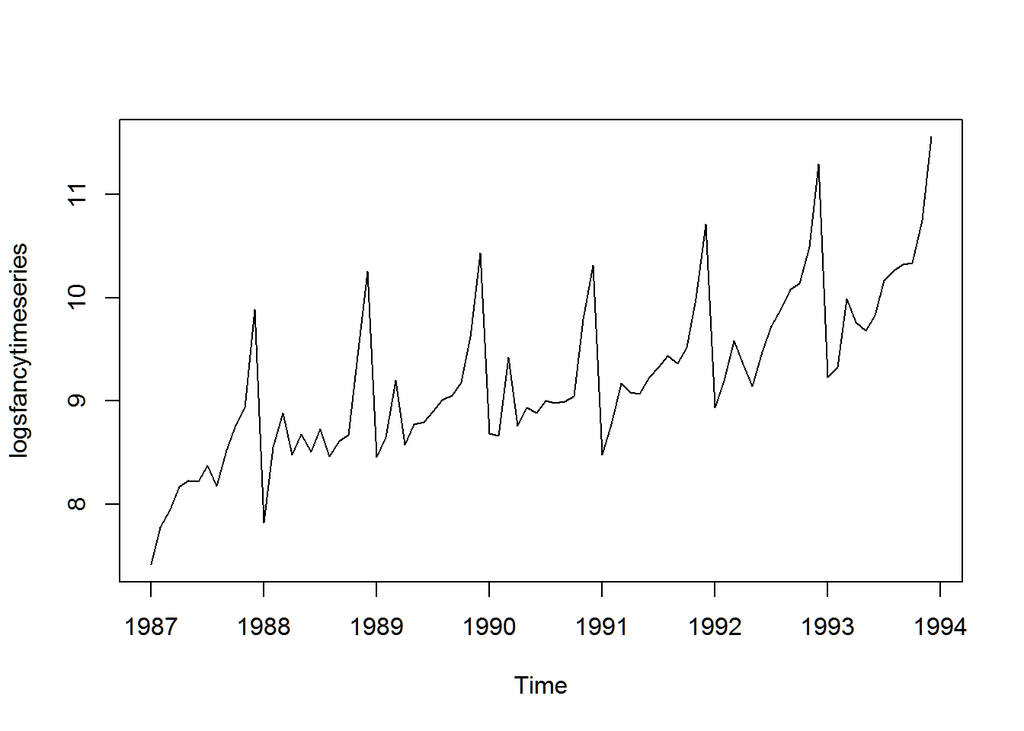

```r
logsfancytimeseries <- log(fancy)
plot.ts(logsfancytimeseries)
```

Here we can see that the size of the seasonal fluctuations and random fluctuations in the log-transformed time series seem to be roughly constant over time, and do not depend on the level of the time series. Thus, the log-transformed time series can probably be described using an additive model.

## c. Use R to fit a regression model to the logarithms of these sales data with a linear trend, seasonal dummies and a “surfing festival” dummy variable.

```r
library(fpp)
logsfancytimeseries = log(fancy)
dummy_surfing_festival = rep(0, length(fancy))
dummy_surfing_festival[seq_along(dummy_surfing_festival)%%12 == 3] <- 1
dummy_surfing_festival[3] <- 0 #festival started one year later
dummy_surfing_festival = ts(dummy_surfing_festival, freq = 12, start=c(1987,1))
fancy_fit_data <- data.frame(
  logsfancytimeseries,
  dummy_surfing_festival
)

fancy_fit = tslm(logsfancytimeseries ~ trend + season + dummy_surfing_festival, data=fancy_fit_data)
#forecast(fancy_fit) Giving error
```

if we omit the dummy_surfing_festival variable, the forecast works fine:

```r
fancy_fit2 = tslm(logsfancytimeseries ~ trend + season, data=fancy_fit_data)
forecast(fancy_fit2)
```

```
##          Point Forecast     Lo 80     Hi 80     Lo 95     Hi 95
## Jan 1994       9.509264  9.246995  9.771532  9.105002  9.913525
## Feb 1994       9.782700  9.520432 10.044969  9.378439 10.186962
## Mar 1994      10.249256  9.986988 10.511525  9.844995 10.653518
## Apr 1994       9.959377  9.697108 10.221645  9.555115 10.363638
## May 1994      10.006830  9.744562 10.269098  9.602569 10.411091
## Jun 1994      10.068191  9.805923 10.330459  9.663930 10.472452
## Jul 1994      10.251837  9.989569 10.514105  9.847576 10.656099
## Aug 1994      10.251367  9.989099 10.513635  9.847106 10.655628
## Sep 1994      10.354752 10.092484 10.617020  9.950491 10.759014
## Oct 1994      10.454834 10.192566 10.717102 10.050573 10.859095
```

While the forecast function is very smart and knows how to extrapolate your trend and season variables, it unfortunately knows nothing about surfing festivals.We need to tell the forecast function when the surfing festival will occur in the future!

For example, here’s a forecast assuming the surfing festival is cancelled, and never happens again:

```r
future_data <- data.frame(
  dummy_surfing_festival = rep(0, 12)
)
forecast(fancy_fit, newdata=future_data)
```

```
##          Point Forecast     Lo 80     Hi 80     Lo 95    Hi 95
## Jan 1994       9.491352  9.238522  9.744183  9.101594  9.88111
## Feb 1994       9.764789  9.511959 10.017620  9.375031 10.15455
## Mar 1994       9.801475  9.461879 10.141071  9.277961 10.32499
## Apr 1994       9.941465  9.688635 10.194296  9.551707 10.33122
## May 1994       9.988919  9.736088 10.241749  9.599161 10.37868
## Jun 1994      10.050280  9.797449 10.303110  9.660522 10.44004
## Jul 1994      10.233926  9.981095 10.486756  9.844168 10.62368
## Aug 1994      10.233456  9.980625 10.486286  9.843698 10.62321
## Sep 1994      10.336841 10.084010 10.589671  9.947083 10.72660
## Oct 1994      10.436923 10.184092 10.689753 10.047165 10.82668
## Nov 1994      10.918299 10.665468 11.171129 10.528541 11.30806
## Dec 1994      11.695812 11.442981 11.948642 11.306054 12.08557
```

## d. Plot the residuals against time and against the fitted values. Do these plots reveal any problems with the model?

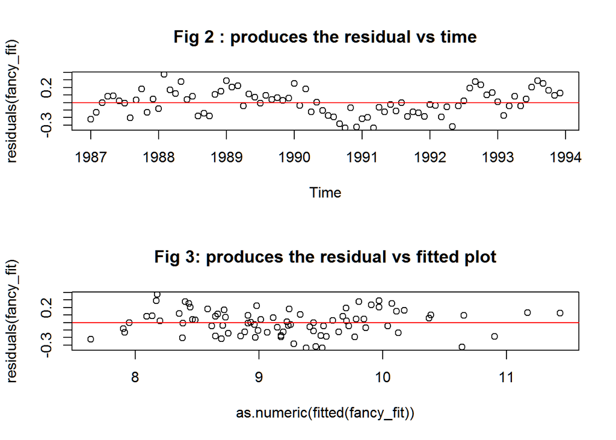

```r
par(mfrow=c(2,1))
plot(residuals(fancy_fit), type='p', main="Fig 2 : produces the residual vs time")
abline(a=0,b=0,col='red')

plot(as.numeric(fitted(fancy_fit)), residuals(fancy_fit), type='p', main="Fig 3: produces the residual vs fitted plot")
abline(a=0,b=0,col='red')
```

## e. Do boxplots of the residuals for each month. Does this reveal any problems with the model?

### Box plot across months will give us a sense on seasonal effect

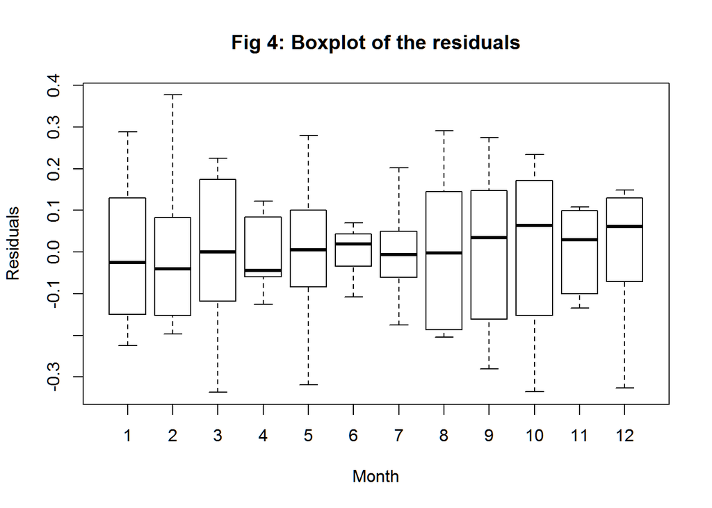

```r
par(mfrow=c(1,1))
boxplot(resid(fancy_fit) ~ cycle(resid(fancy_fit)), main="Fig 4: Boxplot of the residuals", xlab="Month", ylab="Residuals")
```

## f. What do the values of the coefficients tell you about each variable?

```r
#coefficients

fancy_fit
```

```
##
## Call:
## tslm(formula = logsfancytimeseries ~ trend + season + dummy_surfing_festival,
##     data = fancy_fit_data)
##
## Coefficients:
##            (Intercept)                   trend                 season2
##                7.61967                 0.02202                 0.25142
##                season3                 season4                 season5
##                0.26608                 0.38405                 0.40949
##                season6                 season7                 season8
##                0.44883                 0.61045                 0.58796
##                season9                season10                season11
##                0.66933                 0.74739                 1.20675
##               season12  dummy_surfing_festival
##                1.96224                 0.50152
```

## g. What does the Durbin-Watson statistic tell you about your model?

```r
dwtest(fancy_fit, alt="two.sided")
```

```
##
##  Durbin-Watson test
##
## data:  fancy_fit
## DW = 0.88889, p-value = 1.956e-07
## alternative hypothesis: true autocorrelation is not 0
```

In R, the function durbinWatsonTest() verifies if the residuals from a linear model are correlated or not: The null hypothesis (H0) is that there is no correlation among residuals, i.e., they are independent.The alternative hypothesis (Ha) is that residuals are autocorrelated.As the p value was near from zero it means one can reject the null.

Hence here this shows that the residuals are autocorrelated and so the p-value is bellow the level zero, then it means it accepts the alternative hypothesis and rejects the null hypothesis.

## h. Regardless of your answers to the above questions, use your regression model to predict the monthly sales for 1994, 1995, and 1996. Produce prediction Intervals for each of your forecasts.

Prediction Intervals for each of your forecasts is

```r
my_future_data <- data.frame(
  dummy_surfing_festival = rep(0, 36)
)
preds_fancy_fit <- forecast(fancy_fit, newdata=my_future_data)
preds_fancy_fit
```

```
##          Point Forecast     Lo 80     Hi 80     Lo 95    Hi 95
## Jan 1994       9.491352  9.238522  9.744183  9.101594  9.88111
## Feb 1994       9.764789  9.511959 10.017620  9.375031 10.15455
## Mar 1994       9.801475  9.461879 10.141071  9.277961 10.32499
## Apr 1994       9.941465  9.688635 10.194296  9.551707 10.33122
## May 1994       9.988919  9.736088 10.241749  9.599161 10.37868
## Jun 1994      10.050280  9.797449 10.303110  9.660522 10.44004
## Jul 1994      10.233926  9.981095 10.486756  9.844168 10.62368
## Aug 1994      10.233456  9.980625 10.486286  9.843698 10.62321
## Sep 1994      10.336841 10.084010 10.589671  9.947083 10.72660
## Oct 1994      10.436923 10.184092 10.689753 10.047165 10.82668
## Nov 1994      10.918299 10.665468 11.171129 10.528541 11.30806
## Dec 1994      11.695812 11.442981 11.948642 11.306054 12.08557
## Jan 1995       9.755590  9.499844 10.011336  9.361338 10.14984
## Feb 1995      10.029027  9.773281 10.284773  9.634775 10.42328
## Mar 1995      10.065713  9.722498 10.408928  9.536620 10.59481
## Apr 1995      10.205703  9.949957 10.461449  9.811451 10.59996
## May 1995      10.253157  9.997411 10.508903  9.858904 10.64741
## Jun 1995      10.314518 10.058772 10.570264  9.920265 10.70877
## Jul 1995      10.498164 10.242418 10.753910 10.103911 10.89242
## Aug 1995      10.497694 10.241948 10.753440 10.103441 10.89195
## Sep 1995      10.601079 10.345333 10.856825 10.206826 10.99533
## Oct 1995      10.701161 10.445415 10.956907 10.306908 11.09541
## Nov 1995      11.182537 10.926791 11.438282 10.788284 11.57679
## Dec 1995      11.960050 11.704304 12.215796 11.565797 12.35430
## Jan 1996      10.019828  9.760564 10.279093  9.620151 10.41951
## Feb 1996      10.293265 10.034000 10.552530  9.893588 10.69294
## Mar 1996      10.329951  9.982679 10.677222  9.794605 10.86530
## Apr 1996      10.469941 10.210677 10.729206 10.070264 10.86962
## May 1996      10.517395 10.258130 10.776659 10.117718 10.91707
## Jun 1996      10.578756 10.319491 10.838021 10.179079 10.97843
## Jul 1996      10.762402 10.503137 11.021667 10.362725 11.16208
## Aug 1996      10.761932 10.502667 11.021196 10.362254 11.16161
## Sep 1996      10.865317 10.606052 11.124582 10.465640 11.26499
## Oct 1996      10.965399 10.706134 11.224664 10.565722 11.36508
## Nov 1996      11.446774 11.187510 11.706039 11.047097 11.84645
## Dec 1996      12.224288 11.965023 12.483552 11.824611 12.62396
```

## i. Transform your predictions and Intervals to obtain predictions and Intervals for the raw data.

```r
data_f <- as.data.frame(preds_fancy_fit)
data_f <- exp(data_f)
data_f
```

```
##          Point Forecast     Lo 80     Hi 80      Lo 95     Hi 95
## Jan 1994       13244.70  10285.82  17054.73   8969.583  19557.43
## Feb 1994       17409.81  13520.45  22418.00  11790.284  25707.73
## Mar 1994       18060.36  12860.02  25363.61  10699.594  30484.96
## Apr 1994       20774.16  16133.21  26750.16  14068.696  30675.62
## May 1994       21783.73  16917.24  28050.15  14752.395  32166.37
## Jun 1994       23162.27  17987.81  29825.24  15685.969  34201.95
## Jul 1994       27831.56  21613.98  35837.72  18848.111  41096.73
## Aug 1994       27818.48  21603.82  35820.87  18839.249  41077.41
## Sep 1994       30848.42  23956.87  39722.43  20891.193  45551.50
## Oct 1994       34095.57  26478.61  43903.67  23090.230  50346.32
## Nov 1994       55176.84  42850.31  71049.28  37366.903  81475.41
## Dec 1994      120067.79  93244.59 154607.08  81312.400 177294.90
## Jan 1995       17250.40  13357.65  22277.59  11629.938  25587.08
## Feb 1995       22675.20  17558.28  29283.31  15287.252  33633.55
## Mar 1995       23522.50  16688.88  33154.31  13858.024  39926.92
## Apr 1995       27057.06  20951.33  34942.16  18241.435  40133.06
## May 1995       28371.96  21969.51  36640.25  19127.918  42083.42
## Jun 1995       30167.42  23359.80  38958.95  20338.387  44746.58
## Jul 1995       36248.88  28068.91  46812.70  24438.412  53767.06
## Aug 1995       36231.84  28055.72  46790.69  24426.922  53741.78
## Sep 1995       40178.16  31111.50  51887.06  27087.467  59595.26
## Oct 1995       44407.37  34386.35  57348.77  29938.733  65868.34
## Nov 1995       71864.42  55647.40  92807.48  48449.831 106594.69
## Dec 1995      156380.86 121091.75 201954.08 105429.448 231955.81
## Jan 1996       22467.57  17336.40  29117.46  15065.329  33506.86
## Feb 1996       29533.04  22788.25  38274.14  19802.984  44043.89
## Mar 1996       30636.60  21648.24  43356.94  17936.708  52328.52
## Apr 1996       35240.15  27191.96  45670.42  23629.808  52555.15
## May 1996       36952.72  28513.41  47889.88  24778.151  55109.18
## Jun 1996       39291.20  30317.82  50920.48  26346.183  58596.65
## Jul 1996       47211.93  36429.60  61185.57  31657.322  70409.18
## Aug 1996       47189.73  36412.48  61156.80  31642.439  70376.07
## Sep 1996       52329.57  40378.47  67817.91  35088.887  78041.33
## Oct 1996       57837.85  44628.77  74956.52  38782.394  86256.08
## Nov 1996       93598.96  72222.70 121302.09  62761.521 139588.15
## Dec 1996      203676.38 157160.50 263959.89 136572.460 303751.35
```

## j. How could you improve these predictions by modifying the model?

Since in durbinWatsonTest() shows that the residuals are autocorrelated so dynamic-regression model which improves these predictions.

# Question 2:

The data below (data set texasgas) shows the demand for natural gas and the price of natural gas for 20 towns in Texas in 1969.

## a. Do a scatterplot of consumption against price. The data are clearly not linear. Three possible nonlinear models for the data are given below

```r
#Loading the data and lib
library(fma)
library(fpp)
library(segmented)
```

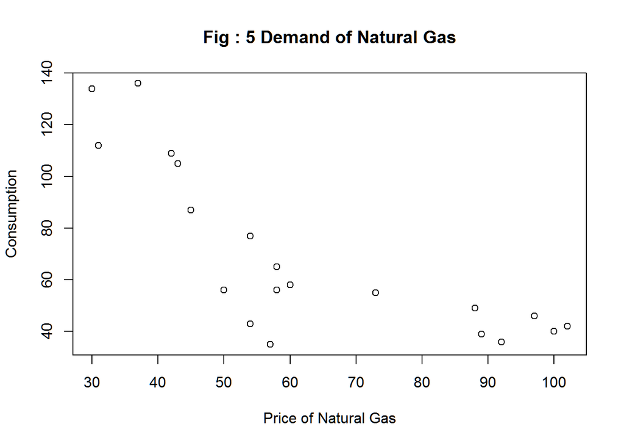

```r
par(mfrow=c(1,1))
my_texasgas_data <- (texasgas)
plot(my_texasgas_data$price, my_texasgas_data$consumption,main="Fig : 5 Demand of Natural Gas" , xlab = "Price of Natural Gas", ylab = "Consumption")
```

## b. Can you explain why the slope of the fitted line should change with P?

All the models are non-linear where the second model divides the data into two sections, depending on whether the price is above or below 60 cents per 1,000 cubic feet. Since the data is non-linear its required to change the slope of the fitted line should change with to cpature information in the models deployed further.

## c. Fit the three models and find the coefficients, and residual variance in each case.

### Model 1: Basic Linear regression

```r
fit_linear <- lm(consumption ~ exp(price), my_texasgas_data)
fit_linear
```

```
##
## Call:
## lm(formula = consumption ~ exp(price), data = my_texasgas_data)
##
## Coefficients:
## (Intercept)   exp(price)
##   7.086e+01   -1.642e-43
```

```r
(summary(fit_linear)$sigma)**2
```

```
## [1] 1101.359
```

### Model 2: piecewise Linear regression

```r
piecewise_fit_linear <- lm(consumption ~ price, my_texasgas_data)
Piecewise_model <- segmented(piecewise_fit_linear, seg.Z = ~price, psi=60)

slope(Piecewise_model)
```

```
## $price
##           Est. St.Err. t value CI(95%).l CI(95%).u
## slope1 -3.1470  0.5102  -6.169   -4.2290   -2.0660
## slope2 -0.3075  0.2220  -1.385   -0.7782    0.1632
```

The slope for B1 is -3.147 and B2 for it’s -0.3075. we have the Residual variance as;

```r
(summary(Piecewise_model)$sigma)**2
```

```
## [1] 167.8511
```

### Model 3: Polynomial regression

```r
Polinomial_fit <- lm(consumption ~ poly(price, 2), my_texasgas_data)
```

we have the Residual variance as;

```r
(summary(Polinomial_fit)$sigma)**2
```

```
## [1] 206.5276
```

A polynomial fit greatly reduces residual variance from the Model 1.

## d. For each model, find the value of R2 and AIC, and produce a residual plot. Comment on the adequacy of the three models.

### Model 1: Basic Linear regression

### Adjusted R-squared: -0.004

### AIC: 200.736

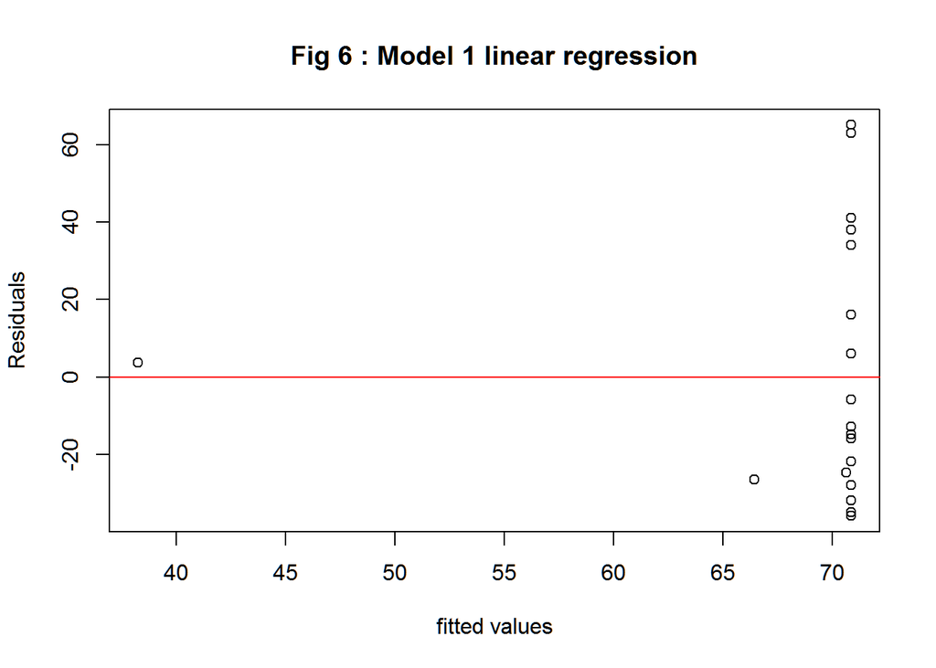

```r
resid <- residuals(fit_linear)
plot(fit_linear$fitted.values, resid, ylab='Residuals', xlab='fitted values',
     main='Fig 6 : Model 1 linear regression')
abline(a=0,b=0,col='red')
```

### Model 2: piecewise Linear regression

### Adjusted R-squared: 0.847

### AIC: 164.756

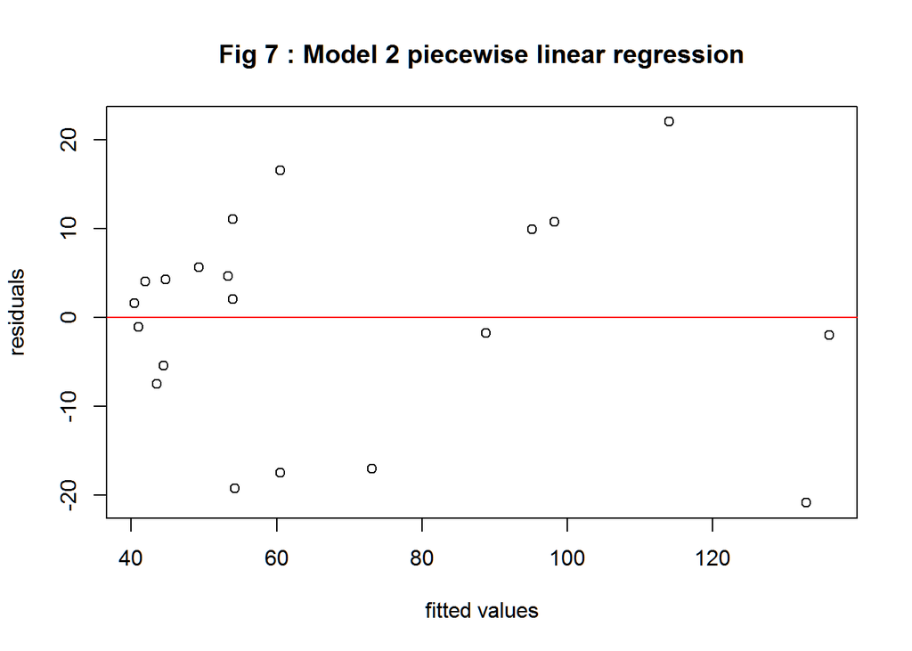

```r
resid <- residuals(Piecewise_model)
plot(Piecewise_model$fitted.values, resid, ylab='residuals', xlab='fitted values',
     main='Fig 7 : Model 2 piecewise linear regression')
abline(a=0,b=0,col='red')
```

### Model 3: Polynomial regression

### Adjusted R-squared: 0.812

### AIC: 168.116

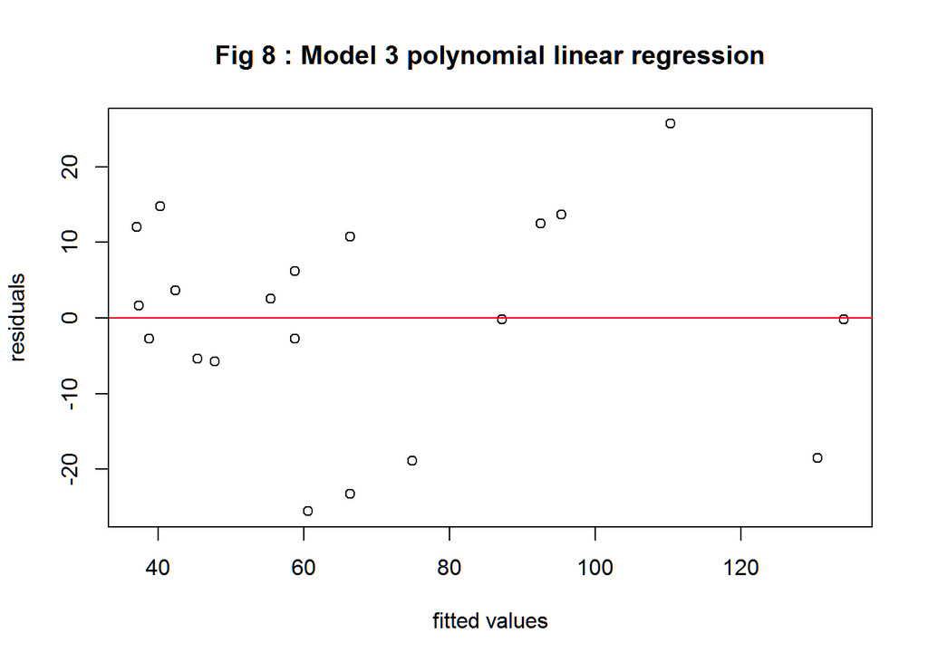

```r
resid <- residuals(Polinomial_fit)
plot(Polinomial_fit$fitted.values, resid, ylab='residuals', xlab='fitted values',
     main='Fig 8 : Model 3 polynomial linear regression')
abline(a=0,b=0,col='red')
```

Resudial plots of the above Model 1 , Model 2 ,Model 3 respectively show heteroskedasticity. Models 1 linear regression model residual plot shows most of these predictions are wildly inaccurate.

Model 2 piecewise model has a slightly larger R square and a slightly lower AIC

## e.For prices 40, 60, 80, 100, and 120 cents per 1,000 cubic feet, compute the forecasted per capita demand using the best model of the three above.

```r
my_new_data <- data.frame(price=c(40, 60, 80, 100, 120))
predict(Piecewise_model, my_new_data)
```

```
##         1         2         3         4         5
## 104.53618  53.34514  47.19593  41.04673  34.89752
```

## f. Compute 95% prediction Intervals. Make a graph of these prediction Intervals and discuss their interpretation.

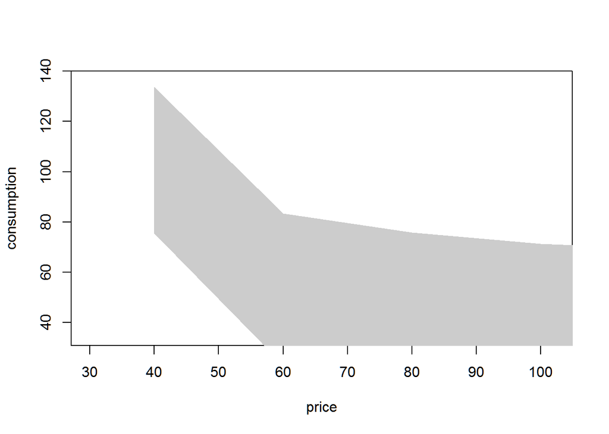

```r
my_new_data_X <- seq(min(my_new_data), max(my_new_data), length.out=5)
Intervals <- predict(Piecewise_model, my_new_data, interval="predict")

plot(consumption ~ price, data = my_texasgas_data, type = 'n')

polygon(c(rev(my_new_data_X), my_new_data_X), c(rev(Intervals[ ,3]), Intervals[ ,2]), col = 'grey80', border = NA)
```

In this it is seen that the prediction levels are wide which can interprets only an idea of how much energy consumption will be in demand in near future.

## g. What is the correlation between P and P2? Does this suggest any general problem to be considered in dealing with polynomial regressions—especially of higher orders?

Consider how large the size of the predictor(s) will be when incorporating higher degree terms as this may cause numerical overflow for the statistical software being used.Do not go strictly by low p-values to incorporate a higher degree term, but rather just use these to support your model only if the resulting residual plots looks reasonable. This is an example of a situation where you need to determine “practical significance” versus “statistical significance”.